# Guided Project: Statistical Transformations and Coordinate Systems

### A3 · Zoom or filter?

```r
a3_table <- a_data %>%
  count(group) %>%
  arrange(desc(n))
a3_table
```

```
# A tibble: 3 × 2
  group               n
  <chr>           <int>
1 Female           2685
2 Male             2313
3 Unknown/Invalid     2
```

```r
a3_start <- 1

a3_counts <- ggplot(a_data, aes(y = group)) +
  geom_bar() +
  labs(x = "Count", y = NULL)

a3_zoom <- a3_counts +
  coord_cartesian(xlim = c(a3_start, max(a3_table$n)), expand = FALSE)

# A warning about removed rows here is expected (Session 2, slide 5).
a3_filter <- a3_counts +
  scale_x_continuous(limits = c(a3_start, max(a3_table$n)))

# Lie Factor (Tufte, 2001, p. 57) of the zoomed plot, largest vs smallest
# group: how many times the picture exaggerates the difference.
a3_largest <- max(a3_table$n)
a3_smallest <- min(a3_table$n)
a3_lie_factor <-
  ((a3_largest - a3_start) / (a3_smallest - a3_start)) /
  (a3_largest / a3_smallest)
a3_lie_factor
```

```
[1] 1.999255
```

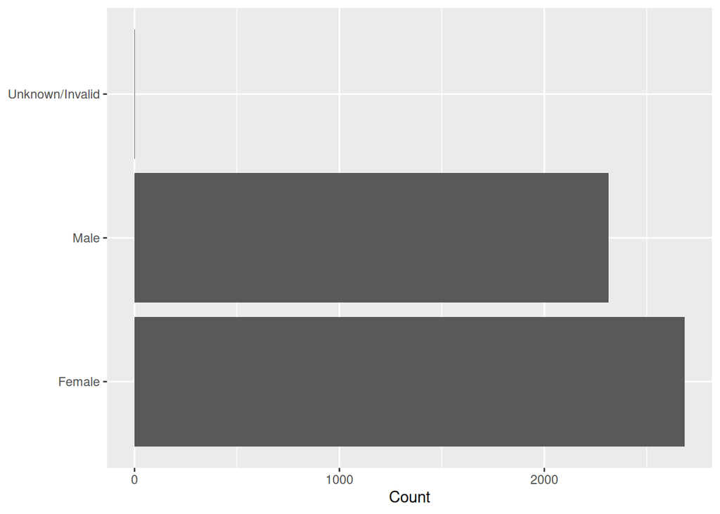

(a) From 0

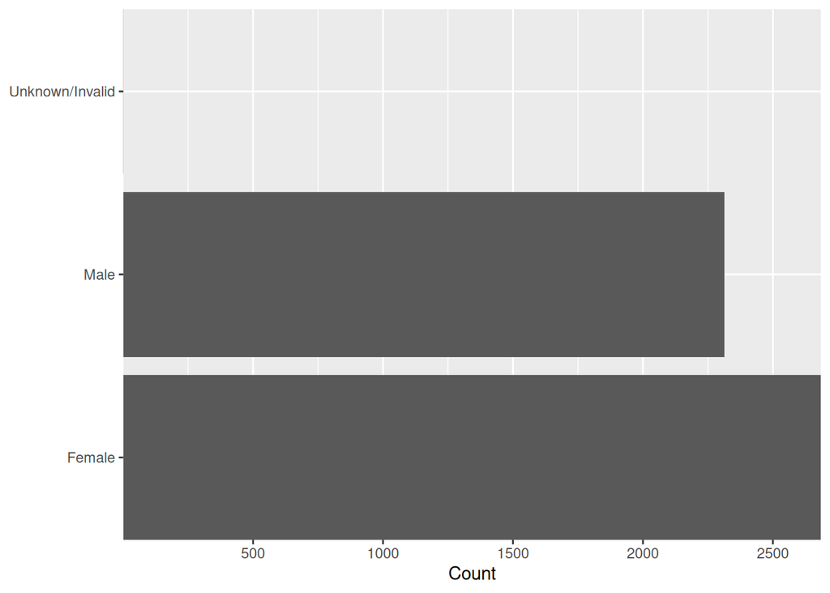

(b) Zoomed

[figure not shown]

(c) Filtered

Figure 3: Counts per group: from 0, zoomed and filtered.

```r
show_plot(a3_counts)
show_plot(a3_zoom)
show_plot(a3_filter)
```

The zoomed plot’s Lie Factor (largest vs smallest group) is 2.

WRITE (3–4 sentences): What does each version show and hide? Explain the Lie Factor in your own words. Which version would you publish, and why?

The first plot shows the actual counts for each group. The zoomed plot makes the differences look bigger, and the filtered plot hides some of the data. The Lie Factor shows how much the picture makes the differences seem larger than they really are. I would use the first plot because it shows the data most clearly and fairly.